# JavaScript has eaten Data Visualization, too.

L Hama

2019-12-17

## Intro

- Alan Turing Institute and Leeds Institute for Data Analytics
- Team: Dr Nik Lomax, Dr Roger Beecham and me.

## JavaScript

> Software is eating the world. And JavaScript is eating software<sub>incldues data vis</sub>.  
> Example # 572639: You can now use JavaScript functions in Excel. https://t.co/x2sNkHv8FR

## Why JS (1)?

> Think of JavaScript as a Dante-like figure, moving from the Netscape rush-job dynamic language hell of the '90s to paradise. Programming Language Theory is Virgil. I won't make more analogies that put real people in circles of hell (but I could!). Anyway, no: JS is not the devil.

## Why JS (2)?

- Web GL (power of the GPU and the CPU)
- Machine Learning (TensorFlow.js - Google)
- Scientific/information visualization (google IEEE VIS 2019 - IEEE)
- Development (VS Code - Microsoft, Atom - github)
- ReactJS (Facebook), Angular (Google/Microsoft) etc.
- ReactNative (smartphone apps transpiled)

## Web mapping (Xerox)

[figure not shown]

## Web mapping (now)

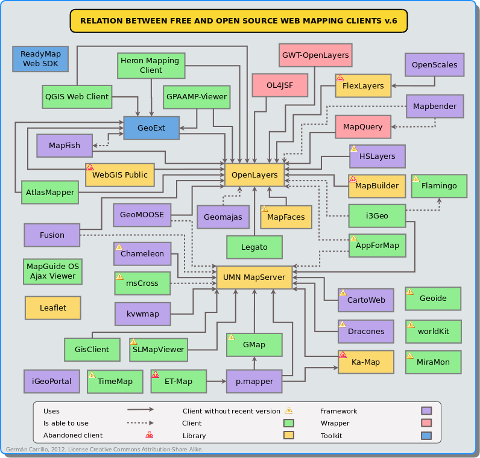

## Web mapping (leading libraries)

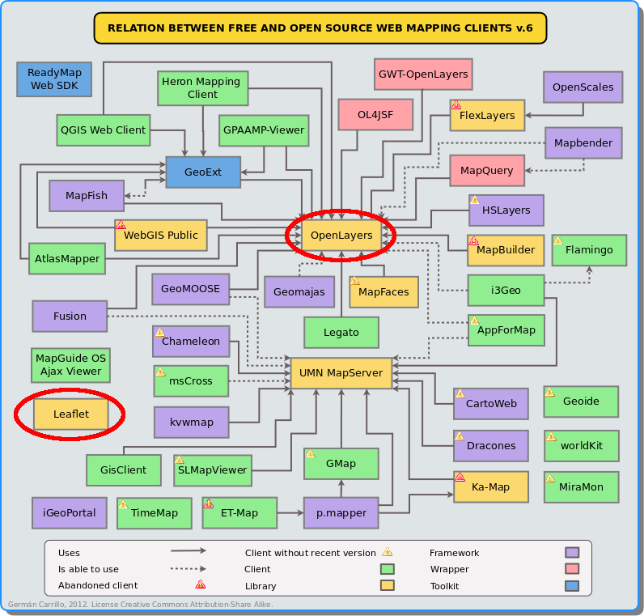

## Web mapping (MapboxGL)

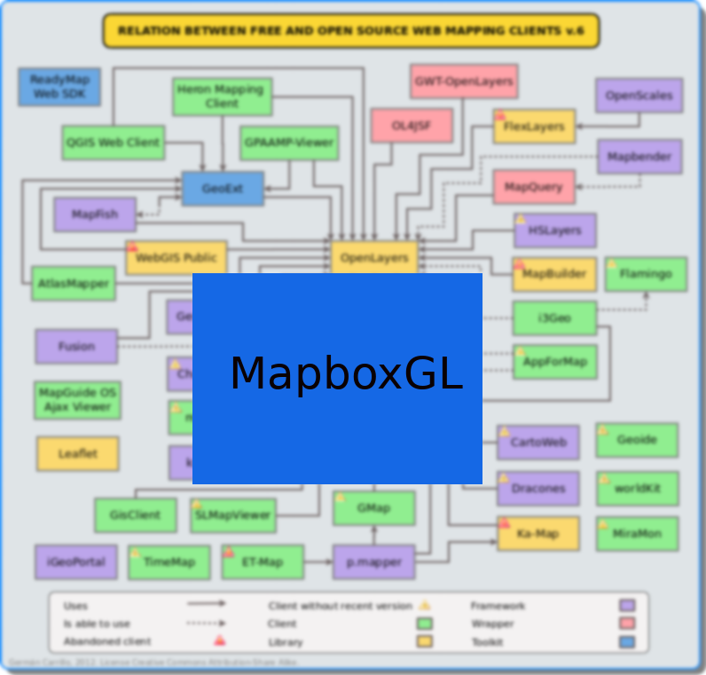

## Data vis

- IEEVIS 2019 in Vancouver best paper tech stack? Yep, the web.

[figure not shown]

## Turing eATlas

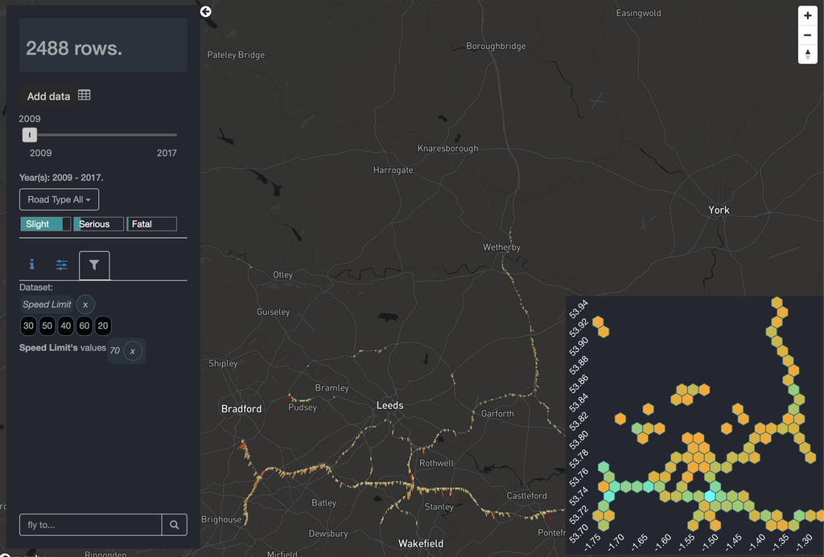

## Techstack

- WebGL powering Uber’s DeckGL
- Uber’s baseweb.design to manage HTML
- Uber’s React-vis powering the charts/graphs (D3)

## Aim?

- Dissecting geospatial datasets.

## JS

Thank you

## Questions?

Links:

- flowsense: https://visflow.org/demo/
- github.com/layik/eAtlas